# TP EEAA - Análisis de salarios con regresión por cuantiles

## 1. Datos

Los datos utilizados provienen de un conjunto de avisos laborales publicados en **Glassdoor** para el sector **tech** (principalmente puestos vinculados a programación, ciencia de datos y desarrollo de software).

El conjunto original incluye información detallada sobre ubicación del puesto, tipo de empresa, descripción del trabajo, lenguaje de programación requerido y otras características. Para este trabajo práctico se utiliza una versión simplificada centrada en las variables:

- **Age**: edad de la persona (años).
- **Gender**: género declarado (Male / Female).
- **Education.Level**: máximo nivel educativo alcanzado (High School, Bachelor’s Degree, Master’s Degree, PhD).
- **Job.Title**: título del puesto en el sector tech.
- **Years.of.Experience**: años de experiencia laboral.
- **Salary**: salario estimado anual en USD.

Es importante remarcar que se trata de **datos observacionales** y de un subconjunto de empresas y postulantes que publican en Glassdoor, por lo que los resultados no necesariamente representan a todo el mercado laboral, pero sí permiten analizar patrones plausibles dentro del sector tecnológico.

## 2. Exploración inicial de los datos

```
## Rows: 5,639
## Columns: 7
## $ Age                 <int> 45, 38, 39, 43, 46, 38, 43, 47, 45, 52, 36, 47, 44…
## $ Gender              <chr> "Male", "Male", "Male", "Female", "Male", "Male", …
## $ Education.Level     <chr> "PhD", "PhD", "PhD", "PhD", "PhD", "PhD", "PhD", "…
## $ Job.Title           <chr> "Senior Manager", "Senior Scientist", "Senior Engi…
## $ Years.of.Experience <dbl> 15, 10, 12, 15, 20, 11, 17, 21, 16, 24, 11, 22, 16…
## $ Salary              <int> 150000, 110000, 115000, 140000, 170000, 120000, 14…
## $ EduYears            <dbl> 21, 21, 21, 21, 21, 21, 21, 21, 21, 21, 21, 21, 21…
```

```
##       Age           Gender          Education.Level     Job.Title
##  Min.   :21.00   Length:5639        Length:5639        Length:5639
##  1st Qu.:28.00   Class :character   Class :character   Class :character
##  Median :32.00   Mode  :character   Mode  :character   Mode  :character
##  Mean   :34.08
##  3rd Qu.:39.00
##  Max.   :62.00
##  Years.of.Experience     Salary          EduYears
##  Min.   : 0.000      Min.   :   500   Min.   :12.00
##  1st Qu.: 3.000      1st Qu.: 65000   1st Qu.:16.00
##  Median : 7.000      Median :110000   Median :18.00
##  Mean   : 8.345      Mean   :111878   Mean   :17.46
##  3rd Qu.:12.000      3rd Qu.:160000   3rd Qu.:18.00
##  Max.   :34.000      Max.   :250000   Max.   :21.00
```

## 3. Distribución de salarios

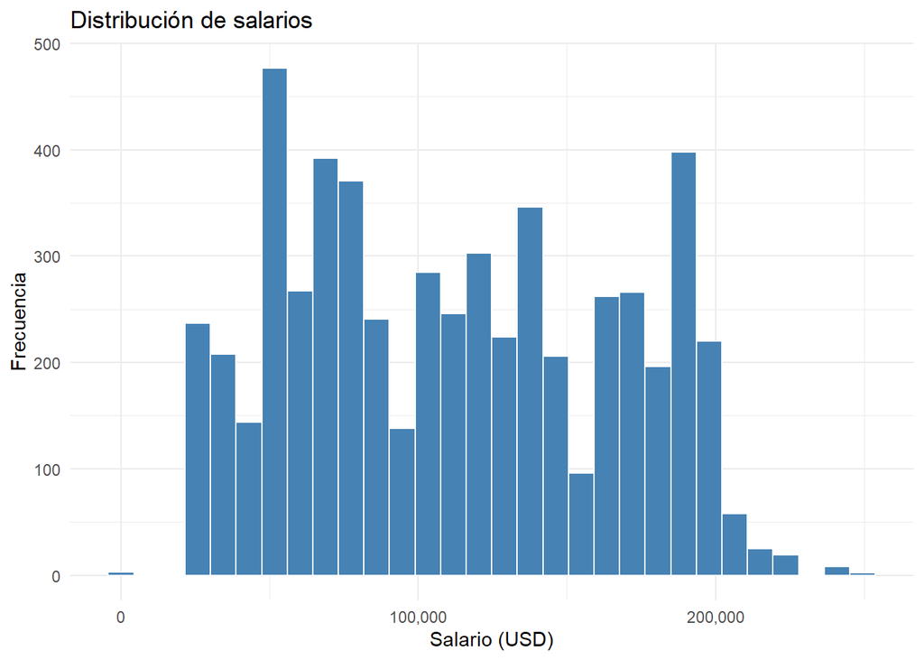

## 4. Boxplot de salario

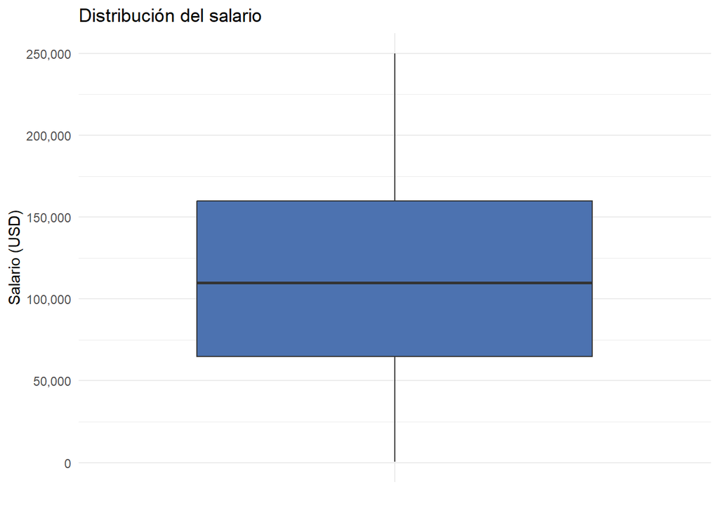

## 5. Salario y género

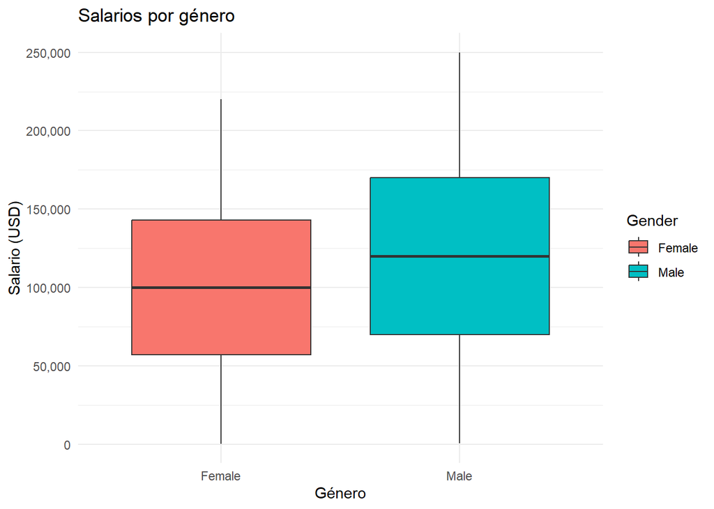

## 6. Salario y Nivel Educativo

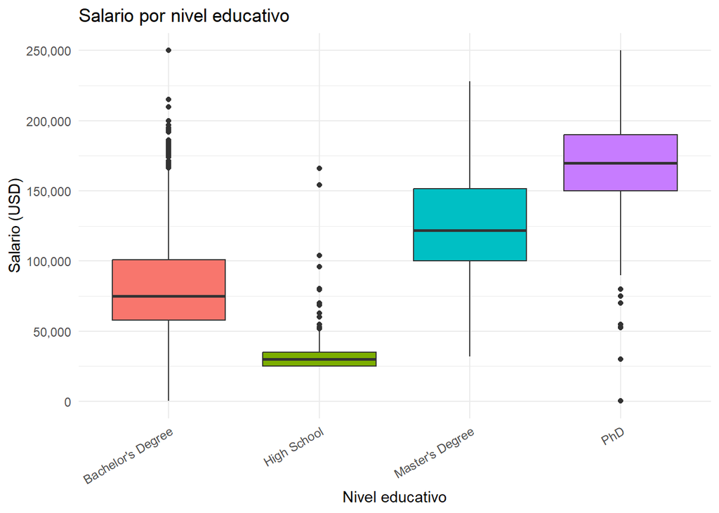

## 7. Salario y Experiencia

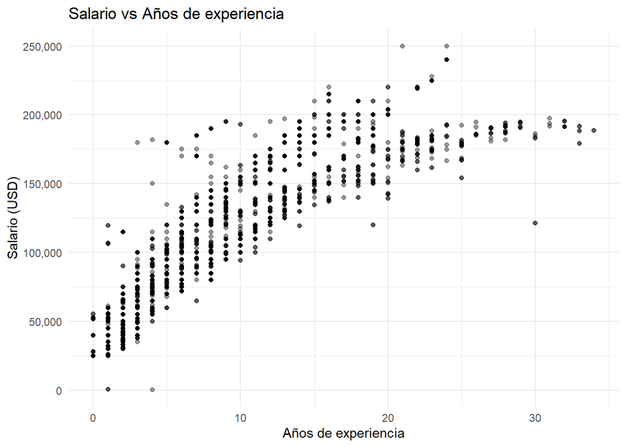

## 4. Diagnóstico del Modelo OLS

```
##
## Call:
## lm(formula = Salary ~ Gender + Education.Level + Years.of.Experience,
##     data = salary)
##
## Residuals:
##     Min      1Q  Median      3Q     Max
## -136854  -13159   -1211   12181   97216
##
## Coefficients:
##                                 Estimate Std. Error t value Pr(>|t|)
## (Intercept)                     49845.18     627.71  79.408   <2e-16 ***
## GenderMale                       5392.44     581.33   9.276   <2e-16 ***
## Education.LevelHigh School     -26705.70    1136.93 -23.489   <2e-16 ***
## Education.LevelMaster's Degree  15017.08     750.87  20.000   <2e-16 ***
## Education.LevelPhD              29245.60     883.09  33.117   <2e-16 ***
## Years.of.Experience              5973.77      58.77 101.652   <2e-16 ***
## ---
## Signif. codes:  0 '***' 0.001 '**' 0.01 '*' 0.05 '.' 0.1 ' ' 1
##
## Residual standard error: 21260 on 5633 degrees of freedom
## Multiple R-squared:  0.8397, Adjusted R-squared:  0.8396
## F-statistic:  5902 on 5 and 5633 DF,  p-value: < 2.2e-16
```

La información que brinda es que cada año de experiencia laboral aumenta en promedio 5973,80 USD (manteniendo constante la educación y el género). También se observa que el hombre gana 5392,40 USD al año más que la mujer. Ambos resultados son estadisticamente significativos (p-value muy pequeño). También se observa cuandos USD al año agrega cada uno de los niveles educativos, lo que permite intuir que estudiar más genera mayores ingresos.

Si bien estos datos son estadisticamente significativos, al observar la información de “Residuals” observamos mucha dispersión, lo que motiva a recurrir a un análisis con técnicas más robustas.

### 4.1. Análisis de Homocedasticidad

El supuesto de homocedasticidad implica que la varianza del error es constante. Lo evaluamos gráficamente (Residuos vs. Ajustados) y con un test formal.

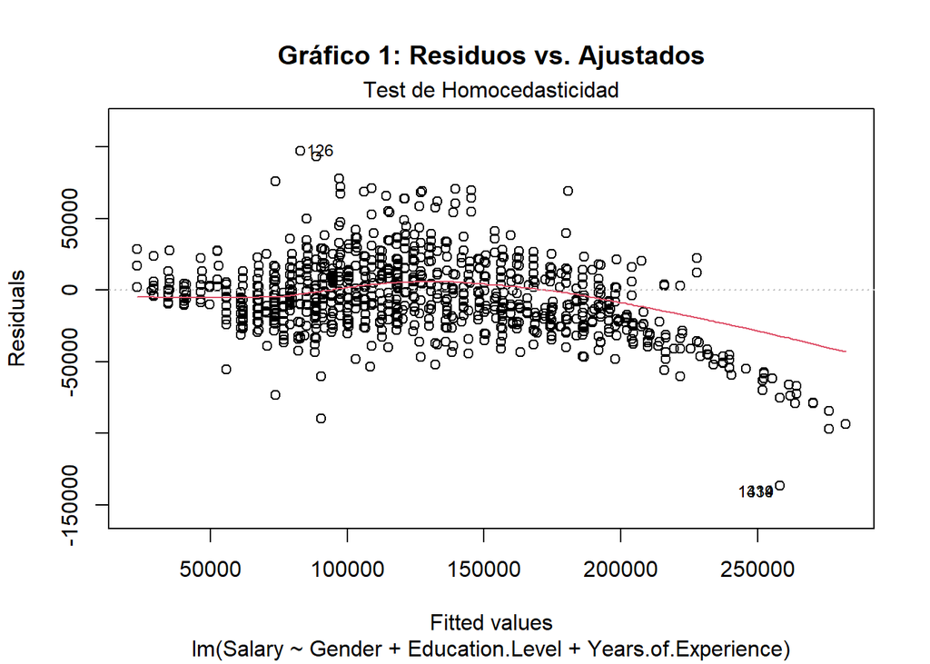

El gráfico muestra que hay violación de los supuestos del modelo OLS. No se observa una dispersión aleatoria alrededor del cero, sino que se observa una asimetría. A su vez, se observa la tendencia (línea roja), y si bien se espera que sea plana y horizontal, esta linea cae, lo que significa que predice sueldos mucho más altos a partir de cierto nivel experiencia y nivel de educación.

```
##
##  studentized Breusch-Pagan test
##
## data:  ols
## BP = 594.12, df = 5, p-value < 2.2e-16
```

Un p-valor muy pequeño (p < 0.05) nos lleva a rechazar la hipótesis nula de homocedasticidad. Esto confirma que la varianza no es constante, violando un supuesto clave de OLS.

### 4.2. Análisis de Normalidad de Residuos

OLS asume que los residuos del modelo siguen una distribución normal.

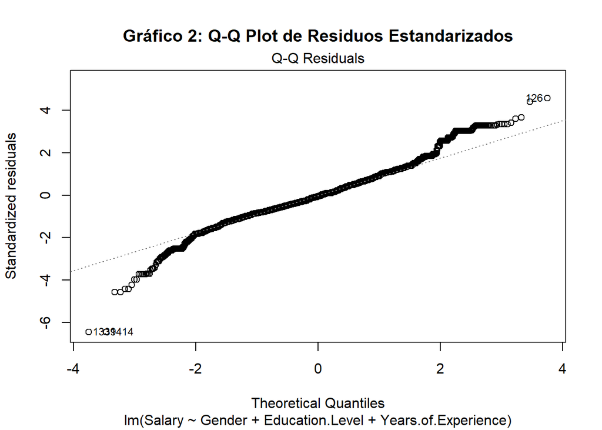

```
##
##  Shapiro-Wilk normality test
##
## data:  sample(residuos, 5000)
## W = 0.97552, p-value < 2.2e-16
```

El gráfico Q-Q de los residuos muestra una fuerte desviación de la línea de normalidad, tanto del lado izquierdo como del lado derecho. Si bien el centro de la distribución se ajusta razonablemente a la normalidad, se observan desviaciones significativas en ambas colas. El test de Shapiro-Wilk confirma (con un p-valor < 0.05) que los residuos no se distribuyen normalmente.

### 4.3. Análisis de Outliers y Puntos Influyentes

La distancia de Cook nos permite identificar puntos influyentes, es decir puntos que son outliers (residuos altos) y tienen alta palanca (leverage, un valor atípico en las X).

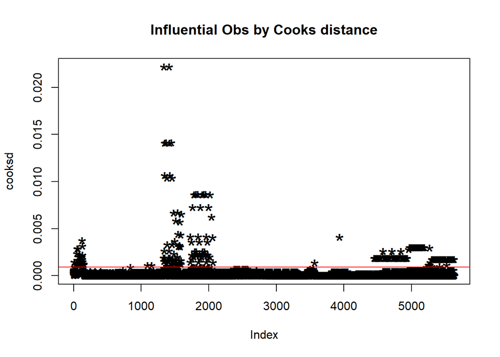

```
##    Age Gender Education.Level                 Job.Title Years.of.Experience
## 12  47   Male             PhD        Research Scientist                  22
## 16  47   Male             PhD Senior Research Scientist                  22
## 18  43 Female             PhD   Senior Product Designer                  18
## 21  42 Female             PhD  Senior Marketing Manager                  18
## 52  30   Male             PhD            Data Scientist                   5
## 53  33   Male             PhD            Data Scientist                   8
##    Salary EduYears
## 12 160000       21
## 16 160000       21
## 18 140000       21
## 21 140000       21
## 52 180000       21
## 53 190000       21
```

El modelo OLS viola los supuestos de normalidad de residuos y homocedasticidad. Por lo tanto, las estimaciones de los coeficientes y sus errores estándar (y, por ende, sus p-valores) no son fiables. Esto justifica plenamente el uso de un método de regresión robusta.

## 8. Modelos de regresión: OLS vs cuantiles

### Modelos de regresión por cuantiles

```
##
## Call: rq(formula = Salary ~ Gender + Education.Level + Years.of.Experience,
##     tau = 0.25, data = salary)
##
## tau: [1] 0.25
##
## Coefficients:
##                                Value        Std. Error   t value
## (Intercept)                     38178.36364    466.20718     81.89141
## GenderMale                       4089.18182    395.11082     10.34946
## Education.LevelHigh School     -19089.18182    406.15801    -46.99940
## Education.LevelMaster's Degree  10910.81818   1352.24863      8.06865
## Education.LevelPhD              25159.36364   1885.92761     13.34058
## Years.of.Experience              5910.81818    116.02279     50.94532
##                                Pr(>|t|)
## (Intercept)                         0.00000
## GenderMale                          0.00000
## Education.LevelHigh School          0.00000
## Education.LevelMaster's Degree      0.00000
## Education.LevelPhD                  0.00000
## Years.of.Experience                 0.00000
```

```
##
## Call: rq(formula = Salary ~ Gender + Education.Level + Years.of.Experience,
##     tau = 0.5, data = salary)
##
## tau: [1] 0.5
##
## Coefficients:
##                                Value        Std. Error   t value
## (Intercept)                     43979.87500   1338.18295     32.86537
## GenderMale                       6939.62500   1058.19473      6.55798
## Education.LevelHigh School     -20000.00000   1241.54533    -16.10896
## Education.LevelMaster's Degree  19698.12500   1734.24582     11.35832
## Education.LevelPhD              38879.25000   2178.90998     17.84344
## Years.of.Experience              6020.12500    166.26683     36.20761
##                                Pr(>|t|)
## (Intercept)                         0.00000
## GenderMale                          0.00000
## Education.LevelHigh School          0.00000
## Education.LevelMaster's Degree      0.00000
## Education.LevelPhD                  0.00000
## Years.of.Experience                 0.00000
```

```
##
## Call: rq(formula = Salary ~ Gender + Education.Level + Years.of.Experience,
##     tau = 0.75, data = salary)
##
## tau: [1] 0.75
##
## Coefficients:
##                                Value        Std. Error   t value
## (Intercept)                     53356.66667   1140.18663     46.79643
## GenderMale                       3014.00000    689.56587      4.37087
## Education.LevelHigh School     -28356.66667   1140.18663    -24.87020
## Education.LevelMaster's Degree  17671.33333   1543.16965     11.45132
## Education.LevelPhD              25685.33333   1929.93199     13.30893
## Years.of.Experience              7328.66667    257.83770     28.42357
##                                Pr(>|t|)
## (Intercept)                         0.00000
## GenderMale                          0.00001
## Education.LevelHigh School          0.00000
## Education.LevelMaster's Degree      0.00000
## Education.LevelPhD                  0.00000
## Years.of.Experience                 0.00000
```

## 9. Gráfico de coeficientes por cuantil

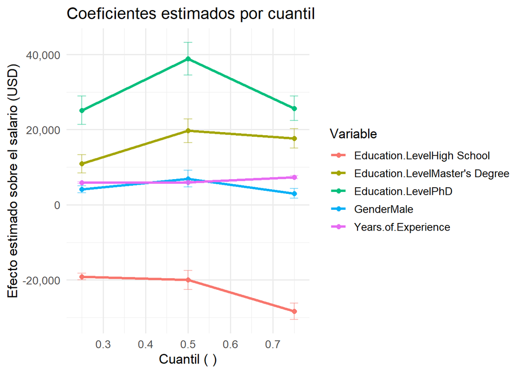

## 9. Regresion por cuantiles VS. OLS

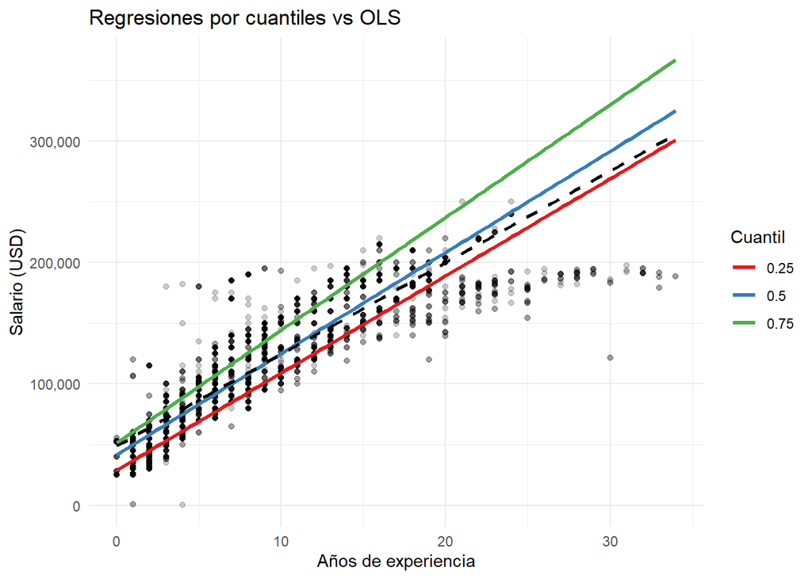

## 5. Modelos de regresión: OLS vs Robusta (M-estimación)

Comparamos el modelo OLS (ya diagnosticado como problemático) con un modelo de Regresión Robusta (M-estimación).

### 5.1. Teoría

- **Regresión OLS (Mínimos Cuadrados Ordinarios):** Estima el efecto promedio minimizando la suma de los errores al cuadrado* Al elevar los residuos al cuadrado, este método penaliza desproporcionadamente los errores grandes. Por ello, es muy sensible a los outliers.
- **Regresión Robusta (M-estimación):** Busca estimar la tendencia estructural de los datos minimizando una función de pérdida que aumenta de forma menos agresiva que el cuadrado para los errores grandes. En este trabajo utilizaremos la estimación MM (Method of Moments), implementada en la función `rlm`. Este método es preferible porque combina una alta eficiencia estadística (como OLS bajo normalidad) con un alto punto de ruptura, lo que significa que puede resistir un porcentaje considerable de outliers y puntos de alta palanca sin que el modelo se rompa. Básicamente, el algoritmo asigna pesos (weights) decrecientes a las observaciones a medida que sus residuos se alejan de lo esperado, reduciendo su influencia en la estimación final.

### 5.2. Estimación de modelos

```
##
## Call:
## lm(formula = Salary ~ Gender + Education.Level + Years.of.Experience,
##     data = salary)
##
## Residuals:
##     Min      1Q  Median      3Q     Max
## -136854  -13159   -1211   12181   97216
##
## Coefficients:
##                                 Estimate Std. Error t value Pr(>|t|)
## (Intercept)                     49845.18     627.71  79.408   <2e-16 ***
## GenderMale                       5392.44     581.33   9.276   <2e-16 ***
## Education.LevelHigh School     -26705.70    1136.93 -23.489   <2e-16 ***
## Education.LevelMaster's Degree  15017.08     750.87  20.000   <2e-16 ***
## Education.LevelPhD              29245.60     883.09  33.117   <2e-16 ***
## Years.of.Experience              5973.77      58.77 101.652   <2e-16 ***
## ---
## Signif. codes:  0 '***' 0.001 '**' 0.01 '*' 0.05 '.' 0.1 ' ' 1
##
## Residual standard error: 21260 on 5633 degrees of freedom
## Multiple R-squared:  0.8397, Adjusted R-squared:  0.8396
## F-statistic:  5902 on 5 and 5633 DF,  p-value: < 2.2e-16
```

```
##
## Call: rlm(formula = Salary ~ Gender + Education.Level + Years.of.Experience,
##     data = salary, method = "MM")
## Residuals:
##       Min        1Q    Median        3Q       Max
## -145927.9  -12000.0    -506.8   12905.1  100898.6
##
## Coefficients:
##                                Value       Std. Error  t value
## (Intercept)                     44013.6917    567.0636     77.6169
## GenderMale                       6869.1547    525.1668     13.0799
## Education.LevelHigh School     -22402.4211   1027.0909    -21.8115
## Education.LevelMaster's Degree  15608.3218    678.3240     23.0101
## Education.LevelPhD              28570.1129    797.7717     35.8124
## Years.of.Experience              6493.1360     53.0891    122.3064
##
## Residual standard error: 16020 on 5633 degrees of freedom
```

## 6. Visualización de Resultados Robustos

### 6.1 ¿A quién “penaliza” el modelo robusto?

rlm funciona asignando “pesos” (weights) a cada observación. Un peso de 1 significa que la observación es “buena” y se usa normalmente. Un peso cercano a 0 significa que la observación es un outlier y su influencia en el modelo se reduce drásticamente.

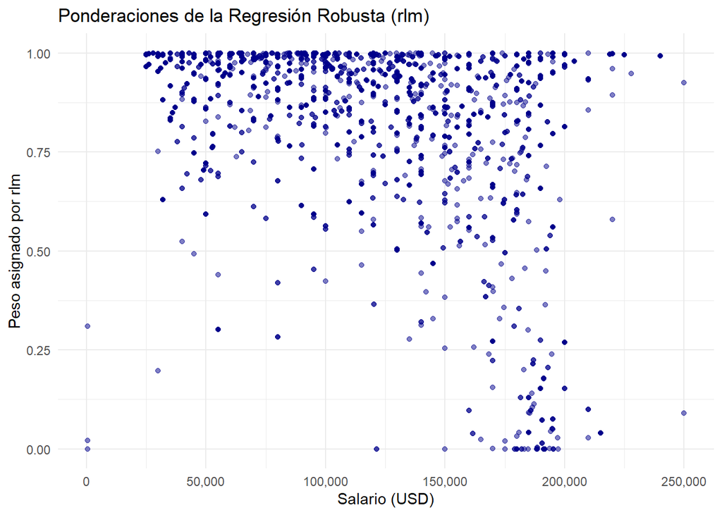

El gráfico muestra a qué datos les cree el modelo y a cuáles no tanto:

Entre los 25.000 y 150.000 USD, confía en la mayoría de los datos, por eso los puntos se mantienen arriba. Son los datos que utiliza para marcar la tendencia.

A partir de los 160.000 USD, los pesos asignados comienzan a tender a cero. El modelo detecta que estos salarios altos son atípicos y les quita influencia para que no distorsionen el resultado.

Por último, los salarios cercanos a 0 son datos que el modelo ignora automáticamente sin necesidad de borrarlos manualmente.

### 6.2 Comparación gráfica de coeficientes

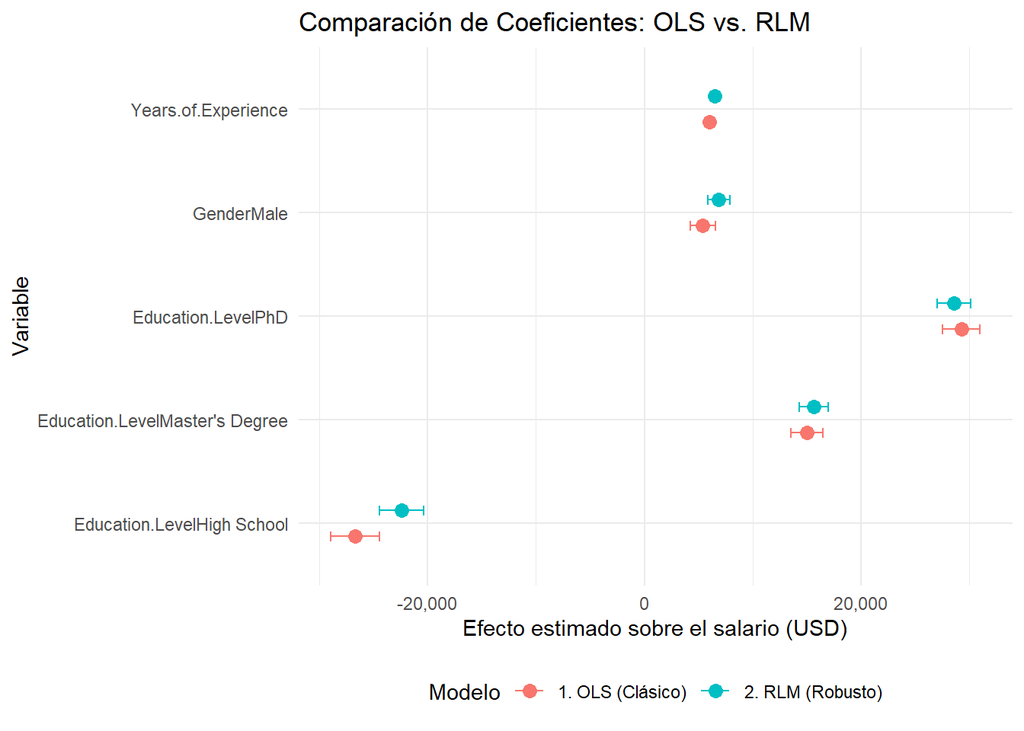